# VESM: Getting Started (Quickstart & Inference)

### Requirements

- Python 3.9+ (recommended), `torch`, `transformers`, `huggingface_hub`, `numpy`, `matplotlib`, `seaborn`
- GPU is optional but recommended for speed
1. Setup & Imports
2. Load a VESM Model
3. Run Inference & Get Scores
4. Visualize Results
5. Download Prediction Scores
6. VESM3 Inference

## 1. Setup & Imports

```python
import torch
from huggingface_hub import hf_hub_download
from transformers import AutoTokenizer, EsmForMaskedLM
import numpy as np
import pandas as pd
import warnings
warnings.simplefilter("ignore", FutureWarning) # ignore future warnings from transformers package
warnings.simplefilter("ignore", UserWarning) # ignore user warnings
```

```python
local_dir = 'vesm' # local directory to store models

print('CUDA available:', torch.cuda.is_available())
if torch.cuda.is_available():
    print('GPU name:', torch.cuda.get_device_name(0))
    device = torch.device('cuda:0')
else:
    device = 'cpu'
```

```
CUDA available: True
GPU name: Tesla T4
```

## 2. Load VESM model

```python
esm_dict = {
    "VESM_3B": 'facebook/esm2_t36_3B_UR50D',
    "VESM_650M": 'facebook/esm2_t33_650M_UR50D',
    "VESM_150M": 'facebook/esm2_t30_150M_UR50D',
    "VESM_35M": 'facebook/esm2_t12_35M_UR50D',
    "VESM3": "esm3_sm_open_v1"
}

def load_vesm(model_name="VESM_3B", local_dir="vesm", device='cuda'):
    if model_name in esm_dict:
        ckt = esm_dict[model_name]
    else:
        print("Model not found")
        return None
    # download weights
    hf_hub_download(repo_id="ntranoslab/vesm", filename=f"{model_name}.pth", local_dir=local_dir)
    # load base model
    if model_name == "VESM3":
      from esm.models.esm3 import ESM3
      model = ESM3.from_pretrained(ckt, device=device).to(torch.float)
      tokenizer = model.tokenizers.sequence
    else:
      model = EsmForMaskedLM.from_pretrained(ckt).to(device)
      tokenizer = AutoTokenizer.from_pretrained(ckt)
    # load pretrained VESM
    model.load_state_dict(torch.load(f'{local_dir}/{model_name}.pth'), strict=False)
    return model, tokenizer
```

We first load the VESM_3B checkpoint from Hugging Face

```python
model_name = 'VESM_3B'
model, tokenizer = load_vesm(model_name, local_dir=local_dir, device=device)
sequence_vocabs = tokenizer.get_vocab()
```

# VESM Inference

The following function is to get log-likelihood ratio (LLR) scores for all possible single missense mutations of a given sequence.

```python
def get_LLR(sequence, esm_model, device='cuda'):
  """
    @param sequence: str, input protein sequence
    @param esm_model: loaded VESM model
    @param device: 'cuda' or 'cpu'
    @return: pd.DataFrame, LLR scores for all missense mutations
  """
  tokens = tokenizer(sequence, return_tensors='pt')
  batch_tokens = tokens['input_ids']
  esm_model.eval()
  with torch.no_grad():
    logits =torch.log_softmax(esm_model(batch_tokens.to(device),)['logits'],dim=-1)[0,:,:].cpu()
  tok = batch_tokens[0,:].cpu()
  wt_norm = logits[np.arange(len(tok)), tok].unsqueeze(1)
  LLR = logits - wt_norm
  LLR=LLR[1:-1,4:24].numpy()
  AAorder=['K','R','H','E','D','N','Q','T','S','C','G','A','V','L','I','M','P','Y','F','W']
  LLR_ = pd.DataFrame(LLR,columns=tokenizer.all_tokens[4:24],index=list(sequence)).T.loc[AAorder]
  LLR_.columns = [j.split('.')[0]+' '+str(i+1) for i,j in enumerate(LLR_.columns)]
  return LLR_
```

## 3. Inference on a protein sequence

```python
protein_sequence = 'MVTLGVISLLENILVIVAIAKNKLHSPMYFFICSLAVADMLVSVSNGSET'
```

compute log-likelihood ratio scores (LLR) for all missense mutations with VESM

```python
get_LLR(protein_sequence, model)
```

|  | M 1 | V 2 | T 3 | L 4 | G 5 | V 6 | I 7 | S 8 | L 9 | L 10 | ... | L 41 | V 42 | S 43 | V 44 | S 45 | N 46 | G 47 | S 48 | E 49 | T 50 |
| --- | --- | --- | --- | --- | --- | --- | --- | --- | --- | --- | --- | --- | --- | --- | --- | --- | --- | --- | --- | --- | --- |
| K | -10.822371 | -10.492038 | -10.032909 | -12.074593 | -12.308662 | -11.508745 | -12.273054 | -12.513042 | -13.270350 | -12.402146 | ... | -13.256907 | -11.394460 | -12.387260 | -10.438471 | -9.992199 | -6.134754 | -6.267148 | -4.923966 | -4.186379 | -5.011253 |
| R | -10.960472 | -10.616226 | -10.427551 | -11.903953 | -11.179332 | -11.740173 | -12.382095 | -11.701332 | -12.464407 | -12.269697 | ... | -12.808197 | -11.261650 | -10.914618 | -10.250938 | -9.344356 | -6.593625 | -5.560264 | -4.677337 | -4.998240 | -5.225631 |
| H | -12.340433 | -11.180683 | -11.048207 | -11.962049 | -12.962646 | -12.276320 | -12.853353 | -12.572961 | -12.915686 | -12.686142 | ... | -12.696777 | -11.837660 | -12.155985 | -10.859955 | -10.233178 | -6.139753 | -6.969481 | -5.396990 | -5.474027 | -5.729684 |
| E | -11.693497 | -9.607013 | -9.867802 | -11.851706 | -10.051706 | -10.770926 | -11.766180 | -11.718824 | -12.941129 | -11.963076 | ... | -12.862934 | -10.560800 | -11.349705 | -9.709038 | -10.128963 | -6.586403 | -5.456844 | -4.734790 | 0.000000 | -5.532529 |
| D | -12.685566 | -10.427269 | -10.097556 | -12.907871 | -9.582980 | -11.492912 | -12.597013 | -10.175653 | -13.652009 | -13.274271 | ... | -13.956408 | -11.139430 | -10.490906 | -10.355329 | -9.688981 | -5.478386 | -5.690769 | -5.119652 | -3.711040 | -5.610915 |
| N | -11.169941 | -9.577675 | -8.131981 | -10.879614 | -10.137535 | -10.130112 | -11.084191 | -8.387293 | -12.616671 | -11.977327 | ... | -12.537696 | -10.263779 | -9.172358 | -9.731142 | -7.521701 | 0.000000 | -5.597553 | -4.286668 | -4.639687 | -4.267188 |
| Q | -10.726421 | -10.365602 | -10.238207 | -10.482025 | -12.357533 | -11.571453 | -11.984052 | -12.804455 | -11.777374 | -11.491954 | ... | -11.479869 | -10.887245 | -12.117645 | -10.435312 | -10.400278 | -6.636487 | -6.595414 | -4.630556 | -4.202578 | -5.375793 |
| T | -8.792629 | -5.562428 | 0.000000 | -7.565638 | -8.550453 | -4.820717 | -5.862652 | -6.848990 | -8.170994 | -6.186397 | ... | -9.056638 | -7.412440 | -6.627877 | -5.857551 | -5.376297 | -4.017408 | -4.678295 | -3.163658 | -4.630418 | 0.000000 |
| S | -9.889250 | -6.644266 | -4.023025 | -8.432316 | -6.165292 | -6.079718 | -7.489322 | 0.000000 | -8.801503 | -7.199616 | ... | -9.466388 | -8.965953 | 0.000000 | -6.816026 | 0.000000 | -3.850566 | -3.779918 | 0.000000 | -4.268334 | -3.144070 |
| C | -11.727165 | -7.902601 | -6.022708 | -9.327583 | -8.278541 | -7.084064 | -7.935820 | -7.311573 | -8.864372 | -7.208694 | ... | -9.664169 | -9.938974 | -7.135561 | -7.542039 | -6.465247 | -6.476344 | -5.557198 | -4.862798 | -6.313693 | -5.727869 |
| G | -11.677663 | -6.873943 | -5.710223 | -10.330283 | 0.000000 | -6.733499 | -8.630748 | -7.540469 | -10.503441 | -8.224139 | ... | -10.738814 | -9.344481 | -6.651278 | -7.519410 | -6.957444 | -5.109447 | 0.000000 | -4.151927 | -4.209623 | -4.695268 |
| A | -9.594446 | -4.805749 | -3.443115 | -7.952073 | -6.293729 | -4.532593 | -5.881722 | -5.692842 | -8.154628 | -5.824290 | ... | -9.215981 | -7.105475 | -5.769110 | -5.183996 | -5.908606 | -5.537041 | -3.855422 | -3.386763 | -4.292204 | -3.236827 |
| V | -8.008522 | 0.000000 | -3.353832 | -5.094507 | -8.839406 | 0.000000 | -2.928473 | -8.809206 | -5.564892 | -3.640239 | ... | -6.696299 | 0.000000 | -8.627457 | 0.000000 | -7.707479 | -5.997550 | -3.880359 | -4.036493 | -4.392256 | -3.774384 |
| L | -7.084240 | -4.337234 | -4.004550 | 0.000000 | -10.274596 | -3.839727 | -3.886573 | -9.838432 | 0.000000 | 0.000000 | ... | 0.000000 | -6.174084 | -8.862851 | -3.979672 | -7.264506 | -6.243035 | -5.028665 | -3.547410 | -4.725915 | -4.133509 |
| I | -7.523157 | -3.402965 | -3.185205 | -4.708851 | -10.283257 | -2.980103 | 0.000000 | -8.803135 | -5.443861 | -3.794059 | ... | -6.420682 | -5.183206 | -9.235838 | -3.275195 | -7.960816 | -5.848906 | -5.036515 | -4.056455 | -5.126071 | -3.777825 |
| M | 0.000000 | -5.285317 | -5.071447 | -5.391759 | -10.295191 | -5.279940 | -5.596798 | -10.336143 | -5.932729 | -5.210485 | ... | -6.154500 | -7.058867 | -10.298141 | -5.538730 | -8.985405 | -6.960690 | -6.074201 | -4.855816 | -5.781785 | -4.601051 |
| P | -11.695125 | -9.976181 | -7.109498 | -11.119626 | -12.087450 | -9.675563 | -10.498446 | -10.674322 | -11.238321 | -10.411281 | ... | -11.477033 | -11.599916 | -9.680343 | -9.097013 | -9.261683 | -7.373016 | -6.497661 | -4.113630 | -5.409083 | -5.107624 |
| Y | -11.652582 | -9.512737 | -9.579838 | -11.148178 | -12.308250 | -10.639788 | -11.448284 | -11.913300 | -12.062540 | -11.161978 | ... | -11.906473 | -11.163565 | -11.204947 | -9.718386 | -8.959290 | -6.921895 | -6.748927 | -4.924813 | -5.720314 | -5.719403 |
| F | -9.438227 | -6.054873 | -5.035018 | -5.814806 | -10.730185 | -5.253207 | -5.295093 | -9.636063 | -5.199723 | -4.653727 | ... | -6.544279 | -8.589806 | -9.444676 | -5.626967 | -7.094066 | -7.392007 | -5.932959 | -4.481818 | -5.770625 | -5.210493 |
| W | -12.039469 | -9.538021 | -9.483986 | -11.114906 | -10.915987 | -10.532311 | -11.013291 | -13.022730 | -10.640679 | -10.140618 | ... | -11.131055 | -11.990395 | -11.915940 | -9.876094 | -9.874310 | -9.205243 | -7.192754 | -6.108626 | -6.922435 | -7.381749 |

20 rows × 50 columns

## 4. Visualizing Results

```python
import seaborn as sns
import matplotlib.pyplot as plt
import plotly.express as px
import plotly.graph_objs as go
from google.colab import output

AAorder=['K','R','H','E','D','N','Q','T','S','C','G','A','V','L','I','M','P','Y','F','W']

def plot_interactive(LLR,higher_than_wt=False,thresh=2,zmax=0,cmap='Viridis_r'):

  TITLE=''

  is_dark = output.eval_js('document.documentElement.matches("[theme=dark]")')
  template='plotly_dark' if is_dark else 'plotly_white'

  fig = px.imshow(LLR.values, x=LLR.columns, y=LLR.index, color_continuous_scale=cmap,zmax=zmax,
                  labels=dict(y="Amino acid change", x="Protein sequence", color="LLR"),
                  template=template,
                  title=TITLE)
  fig.update_xaxes(tickangle=-90,range=[0,99],rangeslider=dict(visible=True),dtick=1)
  fig.update_yaxes(dtick=1)
  fig.update_layout({
  'plot_bgcolor': 'rgba(0, 0, 0, 0)',
  'paper_bgcolor': 'rgba(0, 0, 0, 0)',
  },font={'family':'Arial','size':11},
  hoverlabel=dict(font=dict(family='Arial', size=14)))

  fig.update_traces(
      hovertemplate="<br>".join([
          "<b>%{x} %{y}</b>"+
          " (%{z:.2f})",
      ])+'<extra></extra>'
  )
  if higher_than_wt:
    hwt_x=[]
    hwt_y=[]
    cust=[]
    for i in LLR.columns:
      for j in list(LLR.index[LLR[i]>thresh]):
        hwt_x+=[i]
        hwt_y+=[j]
        cust+=[LLR.loc[j,i]]

    fig.add_trace(go.Scatter(
        x=hwt_x,
        y=hwt_y,
        customdata=cust,
        mode='markers',
        marker=dict(size=8),
        hovertemplate="<br>".join([
            "<b>%{x} %{y}</b>"+
            " (%{customdata:.2f})",
        ])+'<extra></extra>')
    )

  fig.show()


def plot_heatmap(LLR,figname=None,vmin=None):
  """
    Plot a per-residue score heatmap.
      Args:
          scores: 2D array-like of shape (positions, alphabet) or 1D positional scores.
          figname: Optional basename to save PNG.
          range: Color scale range for heatmap.
  """
  primaryLLR=LLR
  plt.figure(figsize=(int(np.round(primaryLLR.shape[1]*90/390)),5))
  sns.heatmap( primaryLLR ,cmap='viridis_r',xticklabels=True, yticklabels=True,vmax=0,vmin=vmin)
  if not figname is None:
    plt.savefig(f"{figname}.png", dpi=300,bbox_inches = 'tight')
  plt.show()
```

### Visualizing LLRs

```python
# MC4R
sequence = 'MVNSTHRGMHTSLHLWNRSSYRLHSNASESLGKGYSDGGCYEQLFVSPEVFVTLGVISLL…'
plot_interactive(get_LLR(sequence, model))
```

### Visualize on Structure

```python
!pip install --quiet py3Dmol biopython
```

```python
import matplotlib
import matplotlib.pyplot as plt
import numpy as np
import py3Dmol
from Bio.SeqUtils import seq1
from Bio.PDB import PDBParser

def show_pdb(position_scores, pdb_file, width=800, height=600, surface=False):
    view = py3Dmol.view(width=width, height=height, js='https://3dmol.org/build/3Dmol.js')
    view.addModel(open(pdb_file, 'r').read(), 'pdb')
    sigmoid_scores = 1 / (1 + np.exp((0.6 * np.array(position_scores) + 6)))
    for i, value in enumerate(sigmoid_scores):
        rgba = plt.cm.coolwarm(value)
        hexcol = matplotlib.colors.rgb2hex(rgba[:3])
        view.setStyle({'resi': str(i+1)}, {'cartoon': {'color': hexcol}})
    view.setBackgroundColor('#383838')

    if surface:
        for i, value in enumerate(sigmoid_scores):
            rgba = plt.cm.coolwarm(value)
            hexcol = matplotlib.colors.rgb2hex(rgba[:3])
            view.addSurface(
                py3Dmol.VDW,
                { 'opacity': 0.7, 'color': hexcol },
                { 'resi': str(i+1) }
            )
        view.setBackgroundColor('white')


    view.zoomTo()
    return view
```

```python
import requests
def download_latest_af_pdb(uniprot_id, version_start=20, version_end=1, out_name=None):
    """
    Download the latest AF PDB model version for a UniProt ID.

    Args:
        uniprot_id (str): UniProt accession, e.g., "P12345"
        version_start (int): Highest version to check, e.g., 10
        version_end (int): Lowest version to check, e.g., 1
        out_name (str): Optional output filename. If None, use the server's name.
    """
    base_url = "https://alphafold.ebi.ac.uk/files"

    for v in range(version_start, version_end - 1, -1):
        url = f"{base_url}/AF-{uniprot_id}-F1-model_v{v}.pdb"
        head = requests.head(url)

        if head.status_code == 200:
            print(f"Found version v{v}: {url}")
            response = requests.get(url)
            response.raise_for_status()

            # Determine filename
            filename = out_name or url.split("/")[-1]
            with open(filename, "wb") as f:
                f.write(response.content)
            print(f"Downloaded to: {filename}")
            return filename

    print(f"No model found for UniProt ID '{uniprot_id}' in versions v{version_start}–v{version_end}.")
    return None
```

Example structure from AFDB

```python
uniprot_id = 'P32245'
pdb_file = download_latest_af_pdb(uniprot_id, version_start=10, version_end=4, out_name=None)
```

```
Found version v6: https://alphafold.ebi.ac.uk/files/AF-P32245-F1-model_v6.pdb
Downloaded to: AF-P32245-F1-model_v6.pdb
```

extract sequence from pdb

```python
sequence = "".join(
    seq1(res.get_resname())
    for res in PDBParser(QUIET=True).get_structure("model", pdb_file).get_residues()
    if res.id[0] == " "
)
```

average scores per position

```python
position_scores = get_LLR(sequence, model).values.mean(0)
show_pdb(position_scores,pdb_file)
```

3Dmol.js failed to load for some reason. Please check your browser console for error messages.

```
<py3Dmol.view at 0x7f75b460f620>
```

## Download Prediction Scores

- **sequence**: input any amino acid sequence for LLR inference.
- **seq_name**: name the sequence for the file name (optional).
- **heatmap**: check if you want to download the LLR heatmap

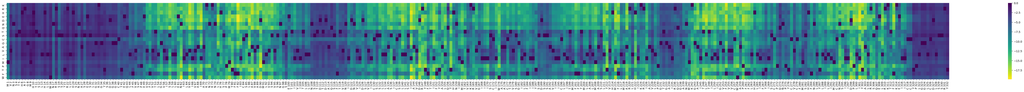

```
Saved results to: vesm_LLR_520a3761_results.zip
```

```python
sequence = 'MVNSTHRGMHTSLHLWNRSSYRLHSNASESLGKGYSDGGCYEQLFVSPEVFVTLGVISLL…' #@param {type:"string"}
seq_name = "" #@param {type:"string"}
heatmap = True #@param {type:"boolean"}

import hashlib, zipfile
from google.colab import files

def short_hash(seq, length=8):
    return hashlib.sha1(seq.encode()).hexdigest()[:length]

def meltLLR(LLR,gene_prefix=None,ignore_pos=False):
  vars = LLR.melt(ignore_index=False)
  vars['variant'] = [''.join(i.split(' '))+j for i,j in zip(vars['variable'],vars.index)]
  vars['score'] = vars['value']
  vars = vars.set_index('variant')
  if not ignore_pos:
    vars['pos'] = [int(i[1:-1]) for i in vars.index]
  del vars['variable'],vars['value']
  if gene_prefix is not None:
    vars.index=gene_prefix+'_'+vars.index
  return vars

base_name = f'vesm_LLR_{seq_name if len(seq_name) > 0 else short_hash(sequence)}'
csv_file = f"{base_name}.csv"
LLR_scores = get_LLR(sequence, model)

# save csv file
meltLLR(LLR_scores).to_csv(csv_file)

if heatmap:
    png_file = f"{base_name}.png"
    plot_heatmap(LLR_scores, figname=base_name, vmin=None)

    # Create results zip with both files
    zip_name = f"{base_name}_results.zip"
    with zipfile.ZipFile(zip_name, 'w') as zipf:
        zipf.write(csv_file)
        zipf.write(png_file)

file_name = zip_name if heatmap else csv_file

print(f"Saved results to: {file_name}")
files.download(file_name)
```

# VESM3 Inference

Downloading the base ESM3-open model requires huggingface login

```python
from huggingface_hub import login
login()
```

```python
!pip install --quiet esm
```

remove previous model (necessary if using Colab's T4 GPU)

```python
if 'model' in globals():
    del model
    torch.cuda.empty_cache()
    import gc; gc.collect()
```

Load VESM3 checkpoint

```python
vesm3, _ = load_vesm("VESM3", local_dir=local_dir, device=device)
```

```python
def get_vesm3_LLR_sequence(sequence, esm3_model):
  from esm.sdk.api import ESMProtein
  protein = ESMProtein(sequence=sequence)
  tokens = esm3_model.encode(protein).sequence
  with torch.no_grad():
    logits =torch.log_softmax(esm3_model.forward(sequence_tokens=tokens.reshape(1,-1)).sequence_logits[0, :, :], dim=-1).cpu()
  tok = tokens.cpu()
  wt_norm = logits[np.arange(len(tok)), tok].unsqueeze(1)
  LLR = logits - wt_norm

  AAorder=['K','R','H','E','D','N','Q','T','S','C','G','A','V','L','I','M','P','Y','F','W']
  order = [esm3_model.tokenizers.sequence.vocab[x] for x in AAorder]
  LLR=LLR[1:-1,order].numpy()
  LLR_ = pd.DataFrame(LLR,columns=AAorder,index=list(sequence)).T
  LLR_.columns = [j.split('.')[0]+' '+str(i+1) for i,j in enumerate(LLR_.columns)]
  return LLR_


def get_vesm3_LLR_structure(pdb_file, esm3_model):
  from esm.sdk.api import ESMProtein
  protein = ESMProtein.from_pdb(pdb_file)
  tokens = esm3_model.encode(protein)
  seq_tokens = tokens.sequence
  struct_tokens = tokens.structure

  with torch.no_grad():
    logits =torch.log_softmax(esm3_model.forward(sequence_tokens=seq_tokens.reshape(1,-1), structure_tokens=struct_tokens.reshape(1,-1) ).sequence_logits[0, :, :], dim=-1).cpu()
  tok = seq_tokens.cpu()
  wt_norm = logits[np.arange(len(tok)), tok].unsqueeze(1)
  LLR = logits - wt_norm

  AAorder=['K','R','H','E','D','N','Q','T','S','C','G','A','V','L','I','M','P','Y','F','W']
  order = [esm3_model.tokenizers.sequence.vocab[x] for x in AAorder]
  LLR=LLR[1:-1,order].numpy()
  LLR_ = pd.DataFrame(LLR,columns=AAorder,index=list(sequence)).T
  LLR_.columns = [j.split('.')[0]+' '+str(i+1) for i,j in enumerate(LLR_.columns)]
  return LLR_
```

```python
### Example structure from AFDB
uniprot_id = 'P32245'
pdb_file = download_latest_af_pdb(uniprot_id, version_start=10, version_end=1, out_name=None)
```

```
Found version v6: https://alphafold.ebi.ac.uk/files/AF-P32245-F1-model_v6.pdb
Downloaded to: AF-P32245-F1-model_v6.pdb
```

```python
from Bio.PDB import PDBParser
from Bio.SeqUtils import seq1
# extract sequence from pdb
sequence = "".join(
    seq1(res.get_resname())
    for res in PDBParser(QUIET=True).get_structure("model", pdb_file).get_residues()
    if res.id[0] == " "
)
```

### Inference with sequence only

```python
LLR_seq = get_vesm3_LLR_sequence(sequence, vesm3)
```

### Inference with structure

```python
LLR_struct = get_vesm3_LLR_structure(pdb_file, vesm3)
```

### Visualize Results

Visualize differences between sequence- and structure- derived LLRs with VESM3

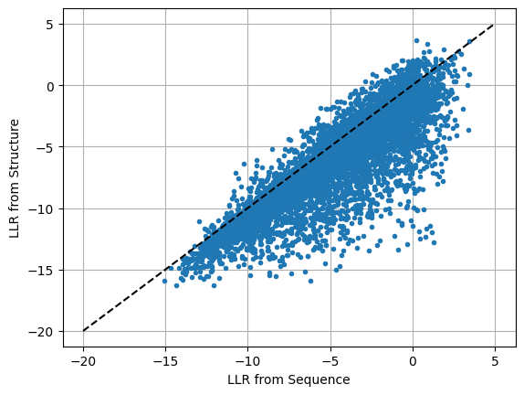

```python
# LLR_seq vs LLR_struct
import matplotlib
import matplotlib.pyplot as plt
plt.plot(LLR_seq.values.reshape(-1), LLR_struct.values.reshape(-1), '.')
plt.plot([-20, 5], [-20, 5], 'k--')
plt.xlabel('LLR from Sequence')
plt.ylabel('LLR from Structure')
plt.grid(True)
plt.show()
```

Plot the heatmap of differences

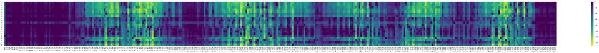

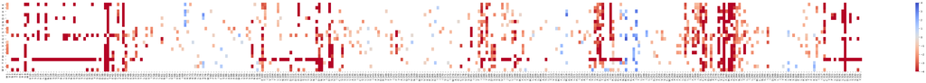

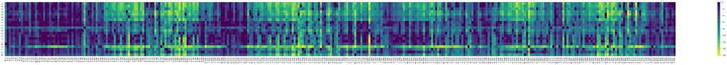

```python
def plot_diff_heatmap(diff,figname=None,range=4):
  plt.figure(figsize=(int(np.round(diff.shape[1]*90/390)),5))
  sns.heatmap( diff ,cmap='coolwarm_r',xticklabels=True, yticklabels=True,vmax=range,vmin=-range)
  if not figname is None:
    plt.savefig(f"{figname}.png", dpi=300,bbox_inches = 'tight')
  plt.show()

diff = LLR_struct - LLR_seq
plot_heatmap(LLR_seq)
threshold = -5
plot_diff_heatmap(diff[((LLR_struct<threshold) & (LLR_seq>threshold)) | ((LLR_struct>threshold) & (LLR_seq<threshold))])
plot_heatmap(LLR_struct)
```